# Predictive Final Project

Holly Michalak

11/21/2019

## Introduction

The objective of this project is to predict energy usage of four different types of meters for various buildings. Intuitively, energy usage will depend on the size of the building, what the building is used for, and the weather at that particular time. All of this data is provided along with many other variables that could potentially predict energy usage in the kaggle competition. The training data contains more than 20 million observations, building metadata, and weather data. This data set also has missing values, which have to be addressed before any meaningful analysis can be done.

## Methods

One of the major hurdles in making these predictions is dealing with the missing data at several steps. While the training data did not have missing values, the supplemental weather and building data did. In the weather data, cloud coverage, precipitation depth, sea level pressure, wind direction, and wind speed all had missing values in varying proportions (figures 1 and 2). Since the weather measurements were taken at regular intervals, time series imputation was used to fill in the missing values. The missingness was not quite as extensive in the building data - only year built and floor count had any missing observations (figures 3 and 4). Conditional mean matching was used to handle these missing values.

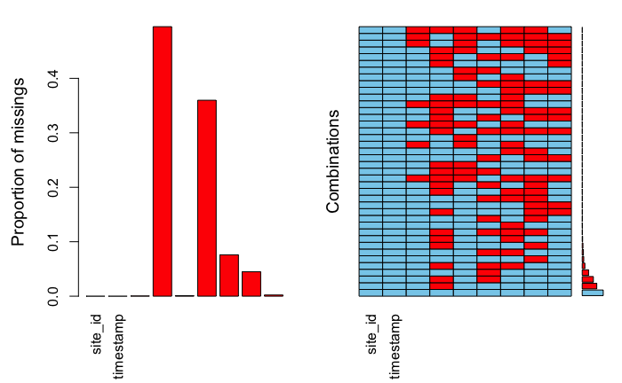

Figure 1

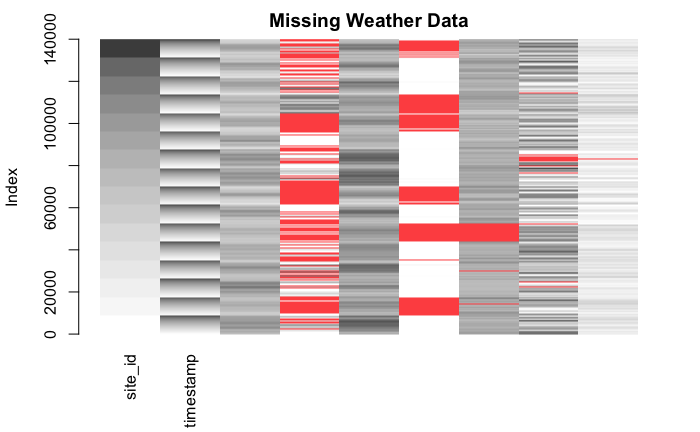

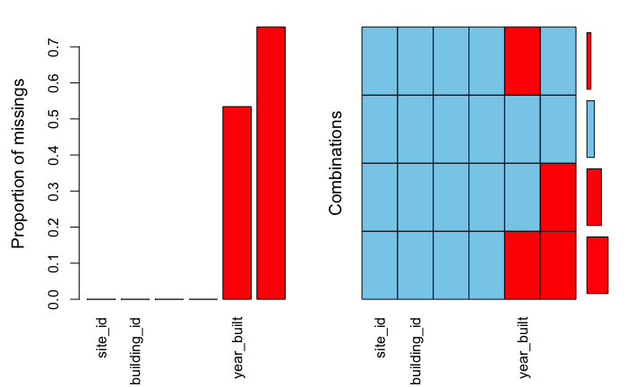

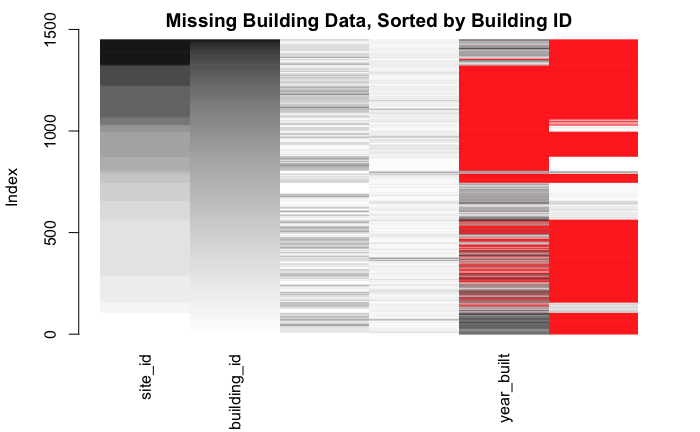

Figure 4

The training data was first merged with the building data. This matched each meter reading with additional information about the appropriate building. Then this new data set was merged with the weather data. Missing data became an issue again at this step. There were more missing values in weather since the time stamps in the training and weather data did not match perfectly. Time series imputation was used again to create a full training data set. Due to computational limitations, a random sample of the training data was chosen and used in the model building.

The sample was then split into four by the meter number and the meter reading was transformed. In order to take advantage of information provided by the time stamp variable, hour of the day, month, year, and day of week variables were created and used in the model building process. A separate GAM model for each meter was built in order to capture how the relationships between the variables might change depending on the meter. Each explanatory variable was plotted against the response with a loess curve added. Figures 5-13 show a selection of these plots.

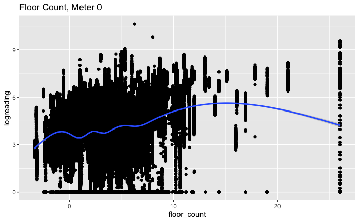

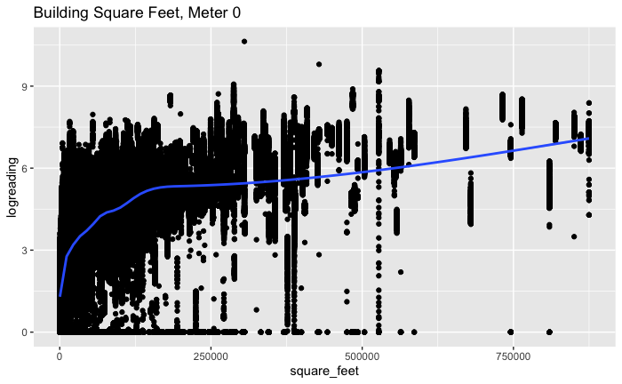

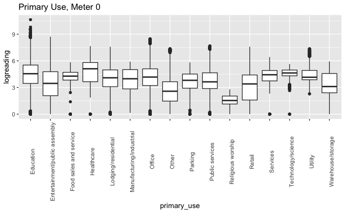

Figure 7

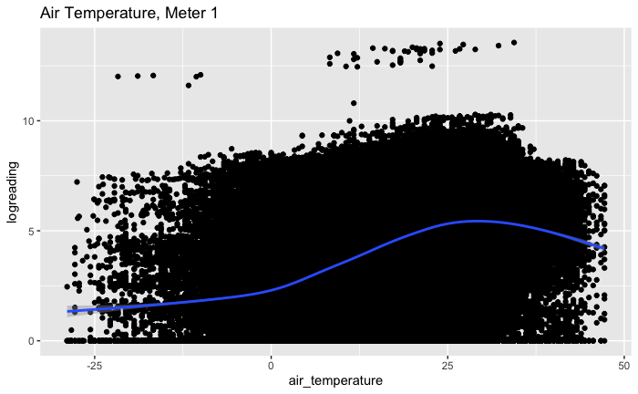

Figure 8

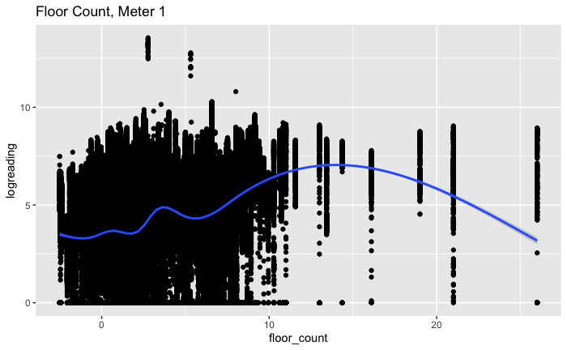

Figure 9

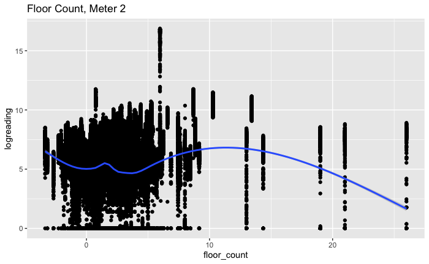

Figure 10

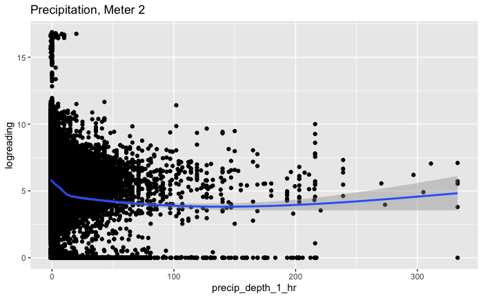

Figure 11

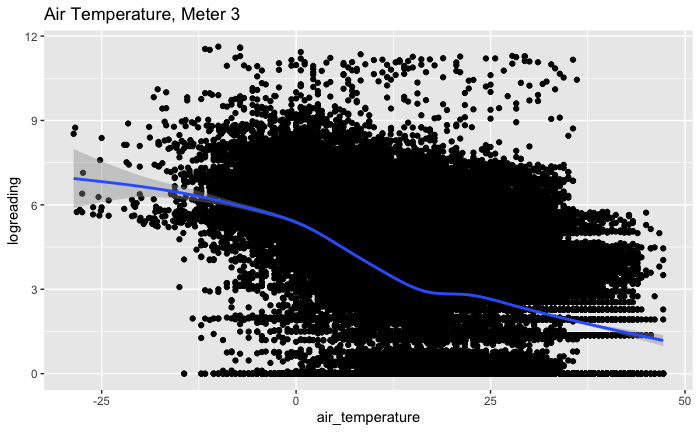

Figure 12

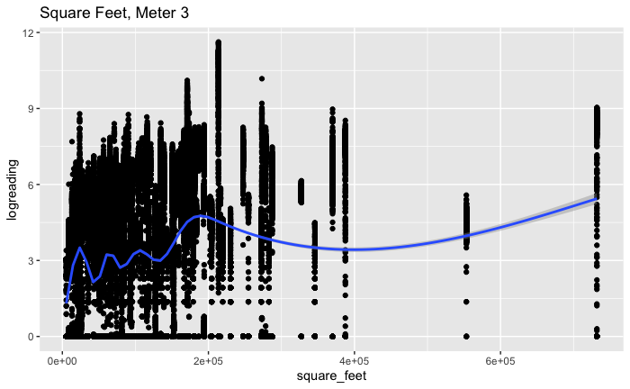

Figure 13

## Conclusion

Using the training, weather, and building data, 4 models were built to predict energy usage meter readings for buildings all over the world. Since the data was large, most of the model building was done on subsets of the data. Missing data was addressed at multiple stages using both conditional mean matching and time series imputation. The final GAM models used the majority of the variables provided to make predictions.

These models can definitely be improved if computational power was not an issue. Fitting the models on the entire training dataset would have been preferable to fitting them on a subset. Both time and access to a powerful enough computer made this difficult. This also would have allowed for using multiple imputation on the missing data instead of just one imputation. In addition, imputing missing values on the full data set would have been better since more variables could have been used to predict the missing values. Overall, taking advantage of the entire dataset and using more computationally expensive techniques certainly would have improved the predictions.

## Appendix

```r
library(tidyverse)
library(lubridate)
library(VIM)
library(mice)
library(imputeTS)
library(ggplot2)
library(gam)
library(MLmetrics)
library(Metrics)
library(data.table)
library(gridExtra)


train <- read.csv("~/Downloads/ashrae-energy-prediction/train.csv")
building <- read.csv("~/Downloads/ashrae-energy-prediction/building_metadata.csv")
weathertrain <- read.csv("~/Downloads/ashrae-energy-prediction/weather_train.csv")


#convert to POSIX
weathertrain$timestamp <- ymd_hms(weathertrain$timestamp)
train$timestamp <- ymd_hms(train$timestamp)

#visualize missing data
aggr(weathertrain)
aggr(building)

matrixplot(building, sortby = "building_id", main = "Missing Building Data, Sorted by Building ID")
matrixplot(weathertrain, sortby = "site_id", main = "Missing Weather Data")

#impute weather first
weather_impute <- na_interpolation(weathertrain, option = "linear")
rm(weathertrain)

#impute building
new_build <- mice(building, m=1, maxit=5, method = "norm.predict")
comp_build <- complete(new_build)
rm(building)

#merge training and building by building ID
merg_dat <- left_join(train, comp_build, by = "building_id")
rm(comp_build,new_build)

#merge training/building with weather data
merg_train <- left_join(merg_dat, weather_impute, by = c("site_id", "timestamp"))
rm(merg_dat, train, weather_impute)

#new missing data
set.seed(9)
impute <- na_interpolation(merg_train, option = "linear")

#add variables to indicate hour of day, month, year, and day of week
impute$hour <- hour(impute$timestamp)
impute$month <- month(impute$timestamp)
impute$year <- year(impute$timestamp)
impute$dayofweek <- weekdays(impute$timestamp)

#want to build on log of meter reading +1
impute$logreading <- log(impute$meter_reading+1)
#subset by meter
set.seed(6)
small <- impute %>% sample_frac(.05)

meter0 <- small %>% filter(meter == 0)
meter1 <- small %>% filter(meter == 1)
meter2 <- small %>% filter(meter == 2)
meter3 <- small %>% filter(meter == 3)


#build model for meter 0

ggplot(data=meter0, aes(x=building_id, y=logreading)) + geom_point()+geom_smooth()


ggplot(data=meter0, aes(x=site_id, y=logreading)) + geom_point()+geom_smooth()

use <- ggplot(data=meter0, aes(x=primary_use, y=logreading)) + geom_boxplot() + ggtitle("Primary Use, Meter 0") + theme(axis.text.x = element_text(angle = 90))
sqft <- ggplot(data=meter0, aes(x=square_feet, y=logreading)) + geom_point()+geom_smooth() + ggtitle("Building Square Feet, Meter 0")
yr_built <- ggplot(data=meter0, aes(x=year_built, y=logreading)) + geom_point()+geom_smooth()+ ggtitle("Year Built, Meter 0")
fl_count <- ggplot(data=meter0, aes(x=floor_count, y=logreading)) + geom_point()+geom_smooth() + ggtitle("Floor Count, Meter 0")
air <- ggplot(data=meter0, aes(x=air_temperature, y=logreading)) + geom_point()+geom_smooth() + ggtitle("Air Temperature, Meter 0")
cloud <- ggplot(data=meter0, aes(x=cloud_coverage, y=logreading)) + geom_point()+geom_smooth() + ggtitle("Cloud Coverage, Meter 0")
dew <- ggplot(data=meter0, aes(x=dew_temperature, y=logreading)) + geom_point()+geom_smooth() + ggtitle("Dew Temperature, Meter 0")
precip <- ggplot(data=meter0, aes(x=precip_depth_1_hr, y=logreading)) + geom_point()+geom_smooth() + ggtitle("Precipitation, Meter 0")

sea_lev <- ggplot(data=meter0, aes(x=sea_level_pressure, y=logreading)) + geom_point()+geom_smooth() + ggtitle("Sea Level Pressure, Meter 0")
wind_dir <- ggplot(data=meter0, aes(x=wind_direction, y=logreading)) + geom_point()+geom_smooth() + ggtitle("Wind Direction, Meter 0")
wind_speed <- ggplot(data=meter0, aes(x=wind_speed, y=logreading)) + geom_point()+geom_smooth() + ggtitle("Wind Speed, Meter 0 ")
hour <- ggplot(data=meter0, aes(x=hour, y=logreading)) + geom_point()+geom_smooth()+ggtitle("Hour, Meter 0")
month <- ggplot(data=meter0, aes(x=month, y=logreading)) + geom_point()+geom_smooth()+ ggtitle("Month, Meter 0")
year <- ggplot(data=meter0, aes(x=year, y=logreading)) + geom_point()+geom_smooth()+ ggtitle("Year, Meter 0")
dayofweek <- ggplot(data=meter0, aes(x=dayofweek, y=logreading)) + geom_point()+geom_smooth()+ggtitle("Day of Week, Meter 0")

#hold out set

set.seed(8)
train_met0 <- sample(1:nrow(meter0), round(602983*0.7), replace = FALSE)
test_met0 <- meter0[-train_met0,]
meter0_gam <- gam(logreading ~ primary_use + square_feet + ns(year_built, df=3) + ns(floor_count, df=4) + ns(air_temperature, df=2) + cloud_coverage + s(dew_temperature, df=7) + s(precip_depth_1_hr, df=2) + ns(sea_level_pressure, df = 5)  + dayofweek, data = meter0[train_met0,])

meter0_preds <- predict(meter0_gam, newdata = test_met0)

rmsle(meter0_preds, test_met0$logreading)

### meter1

ggplot(data=meter1, aes(x=building_id, y=logreading)) + geom_point()+geom_smooth()


ggplot(data=meter1, aes(x=site_id, y=logreading)) + geom_point()+geom_smooth()
ggplot(data=meter1, aes(x=primary_use, y=logreading)) + geom_boxplot()

sq_ft1 <- ggplot(data=meter1, aes(x=square_feet, y=logreading)) + geom_point()+geom_smooth()+ggtitle("Square Feet")

ggplot(data=meter1, aes(x=year_built, y=logreading)) + geom_point()+geom_smooth()


fl_ct1 <- ggplot(data=meter1, aes(x=floor_count, y=logreading)) + geom_point()+geom_smooth() +ggtitle("Floor Count, Meter 1")

air1 <- ggplot(data=meter1, aes(x=air_temperature, y=logreading)) + geom_point()+geom_smooth()+ggtitle("Air Temperature, Meter 1")


ggplot(data=meter1, aes(x=cloud_coverage, y=logreading)) + geom_point()+geom_smooth()


ggplot(data=meter1, aes(x=dew_temperature, y=logreading)) + geom_point()+geom_smooth()

ggplot(data=meter1, aes(x=precip_depth_1_hr, y=logreading)) + geom_point()+geom_smooth()

ggplot(data=meter1, aes(x=sea_level_pressure, y=logreading)) + geom_point()+geom_smooth()


ggplot(data=meter1, aes(x=wind_direction, y=logreading)) + geom_point()+geom_smooth()

ggplot(data=meter1, aes(x=wind_speed, y=logreading)) + geom_point()+geom_smooth()

ggplot(data=meter1, aes(x=hour, y=logreading)) + geom_point()+geom_smooth()

ggplot(data=meter1, aes(x=month, y=logreading)) + geom_point()+geom_smooth()


ggplot(data=meter1, aes(x=year, y=logreading)) + geom_point()+geom_smooth()
```

```r
ggplot(data=meter1, aes(x=dayofweek, y=logreading)) + geom_boxplot() + ggtitle("Day of Week, Meter 1")



set.seed(1)
train_met1 <- sample(1:nrow(meter1), round(nrow(meter1)*0.7), replace=FALSE)
test_met1 <- meter1[-train_met1,]
meter1_gam <- gam(logreading ~ primary_use + ns(square_feet, df=5) + poly(year_built,3) + poly(floor_count, 3) + ns(air_temperature, df = 4) + s(cloud_coverage, df=3) + dew_temperature + poly(precip_depth_1_hr,2) + poly(sea_level_pressure,2) + ns(hour, df=2) + s(month, df=4)  + dayofweek  , data=meter1[train_met1,])

meter1_preds <- predict(meter1_gam, newdata = test_met1)

rmsle(meter1_preds, test_met1$logreading)

##meter 2


ggplot(data=meter2, aes(x=primary_use, y=logreading)) + geom_boxplot()

ggplot(data=meter2, aes(x=square_feet, y=logreading)) + geom_point()+geom_smooth()+ggtitle("Square Feet")

ggplot(data=meter2, aes(x=year_built, y=logreading)) + geom_point()+geom_smooth()+ggtitle("Year Built, Meter 2")


ggplot(data=meter2, aes(x=floor_count, y=logreading)) + geom_point()+geom_smooth() + ggtitle("Floor Count, Meter 2")


ggplot(data=meter2, aes(x=air_temperature, y=logreading)) + geom_point()+geom_smooth()


ggplot(data=meter2, aes(x=cloud_coverage, y=logreading)) + geom_point()+geom_smooth()


ggplot(data=meter2, aes(x=dew_temperature, y=logreading)) + geom_point()+geom_smooth()

ggplot(data=meter2, aes(x=precip_depth_1_hr, y=logreading)) + geom_point()+geom_smooth()+ggtitle("Precipitation, Meter 2")

ggplot(data=meter2, aes(x=sea_level_pressure, y=logreading)) + geom_point()+geom_smooth()


ggplot(data=meter2, aes(x=wind_direction, y=logreading)) + geom_point()+geom_smooth()

ggplot(data=meter2, aes(x=wind_speed, y=logreading)) + geom_point()+geom_smooth()

ggplot(data=meter2, aes(x=hour, y=logreading)) + geom_point()+geom_smooth()

ggplot(data=meter2, aes(x=month, y=logreading)) + geom_point()+geom_smooth()


ggplot(data=meter2, aes(x=year, y=logreading)) + geom_point()+geom_smooth()

ggplot(data=meter2, aes(x=dayofweek, y=logreading)) + geom_point()+geom_smooth()

train_met2 <- sample(1:nrow(meter2), round(nrow(meter2)*0.7), replace=FALSE)
test_met2 <- meter2[-train_met2,]


meter2_gam <- gam(logreading ~ primary_use + square_feet + ns(year_built,df=2) + ns(floor_count, df=2) + air_temperature + ns(cloud_coverage, df=2) + dew_temperature + poly(sea_level_pressure,2) + hour + ns(month,2) + dayofweek, data = meter2[train_met2,])

meter2_preds <- predict(meter2_gam, test_met2)

rmsle(meter2_preds, test_met2$logreading)

#####meter 3


ggplot(data=meter3, aes(x=primary_use, y=logreading)) + geom_boxplot()

ggplot(data=meter3, aes(x=square_feet, y=logreading)) + geom_point()+geom_smooth()+ ggtitle("Square Feet, Meter 3")

ggplot(data=meter3, aes(x=year_built, y=logreading)) + geom_point()+geom_smooth()


ggplot(data=meter3, aes(x=floor_count, y=logreading)) + geom_point()+geom_smooth()


ggplot(data=meter3, aes(x=air_temperature, y=logreading)) + geom_point()+geom_smooth() + ggtitle("Air Temperature, Meter 3")

ggplot(data=meter3, aes(x=cloud_coverage, y=logreading)) + geom_point()+geom_smooth()


ggplot(data=meter3, aes(x=dew_temperature, y=logreading)) + geom_point()+geom_smooth()

ggplot(data=meter3, aes(x=precip_depth_1_hr, y=logreading)) + geom_point()+geom_smooth()

ggplot(data=meter3, aes(x=sea_level_pressure, y=logreading)) + geom_point()+geom_smooth()


ggplot(data=meter3, aes(x=wind_direction, y=logreading)) + geom_point()+geom_smooth()

ggplot(data=meter3, aes(x=wind_speed, y=logreading)) + geom_point()+geom_smooth()

ggplot(data=meter3, aes(x=hour, y=logreading)) + geom_point()+geom_smooth()

ggplot(data=meter3, aes(x=month, y=logreading)) + geom_point()+geom_smooth()


ggplot(data=meter3, aes(x=year, y=logreading)) + geom_point()+geom_smooth()

ggplot(data=meter3, aes(x=dayofweek, y=logreading)) + geom_point()+geom_smooth()

set.seed(3)
train_met3 <- sample(1:nrow(meter3), round(nrow(meter3)*0.7), replace=FALSE)
test_met3 <- meter3[-train_met3,]

meter3_gam <- gam(logreading ~ ns(square_feet, df=2)  + poly(floor_count, 2) + air_temperature + ns(cloud_coverage, df=2) + ns(dew_temperature, df=2) + poly(sea_level_pressure,2), data = meter3[train_met3,])

meter3_preds <- predict(meter3_gam, test_met3)

rmsle(meter3_preds, test_met3$logreading)

#do everything to the test data

weather_test <- read.csv("~/Downloads/ashrae-energy-prediction/weather_test.csv")

#impute weather test

new_weather_test <- na_interpolation(weather_test, option = "linear")
rm(weather_test)

test <- read.csv("~/Downloads/ashrae-energy-prediction/test.csv")
building <- read.csv("~/Downloads/ashrae-energy-prediction/building_metadata.csv")
new_build <- mice(building, m=1, maxit=5, method = "norm.predict")
comp_build <- complete(new_build)
rm(building)
rm(new_build)


test$timestamp <- ymd_hms(test$timestamp)
new_weather_test$timestamp <- ymd_hms(new_weather_test$timestamp)

merg_dat_2 <- left_join(test, comp_build, by = "building_id")
rm(test, comp_build)

test_dat <- left_join(merg_dat_2, new_weather_test, by = c("site_id", "timestamp"))

impute2 <- na_interpolation(test_dat, option = "linear")

impute2$hour <- hour(impute2$timestamp)
impute2$month <- month(impute2$timestamp)
impute2$year <- year(impute2$timestamp)
impute2$dayofweek <- weekdays(impute2$timestamp)


meter0_test <- impute2 %>% filter(meter == 0)
meter1_test <- impute2 %>% filter(meter == 1)
meter2_test <- impute2 %>% filter(meter == 2)
meter3_test <- impute2%>% filter(meter == 3)


#split meter 1
meter0_test1 <- meter0_test[1:round(nrow(meter0_test)*0.5), ]
meter0_test2 <- meter0_test[12377881:nrow(meter0_test), ]

#make predictions
predict_meter01 <- predict(meter0_gam, meter0_test1)
predict_meter02 <- predict(meter0_gam, meter0_test2)
predict_meter1 <- predict(meter1_gam, meter1_test)
predict_meter2 <- predict(meter2_gam, meter2_test)
predict_meter3 <- predict(meter3_gam, meter3_test)



meter0_test1$preds <- predict_meter01
meter0_test2$preds <- predict_meter02
meter1_test$preds <- predict_meter1
meter2_test$preds <- predict_meter2
meter3_test$preds <- predict_meter3
```

```r
met01_entries <- meter0_test1 %>% select(row_id, preds)
met02_entires <- meter0_test2 %>% select(row_id, preds)
met1_entries <- meter1_test %>% select(row_id,preds)
met2_entries <- meter2_test %>% select(row_id, preds)
met3_entires <- meter3_test %>% select(row_id, preds)

new_data <- rbind(met01_entries, met02_entires, met1_entries, met2_entries, met3_entires)

 #transform back
new_data$actual <- exp(new_data$preds-1)

submit <- new_data %>% select(row_id, actual)
names(submit) <- c("row_id", "meter_reading")
```